# Exploratory data analysis

Alboukadel Kassambara

# Total read counts per sample

```
##      BM1      BM2      BM3   actBC1   actBC2   actBC3   prePB1   prePB2   prePB3      PB1      PB2      PB3      PC1      PC2      PC3
## 39340503 32215230 33504976 52609551 31417533 38078193 51434493 49786682 43193916 47465383 45742752 40966390 43718199 44444712 34203576
```

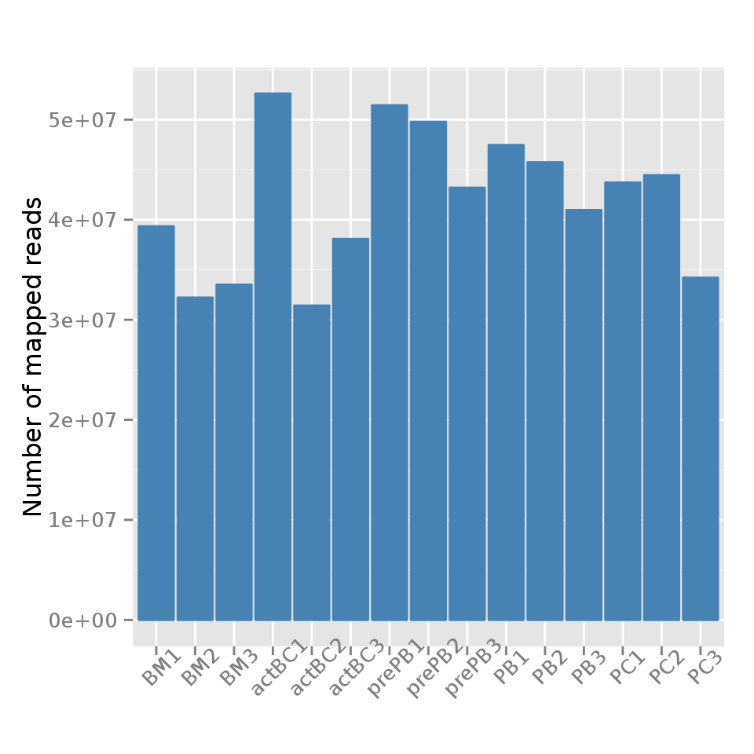

# Distribution of count per sample

## Boxplot

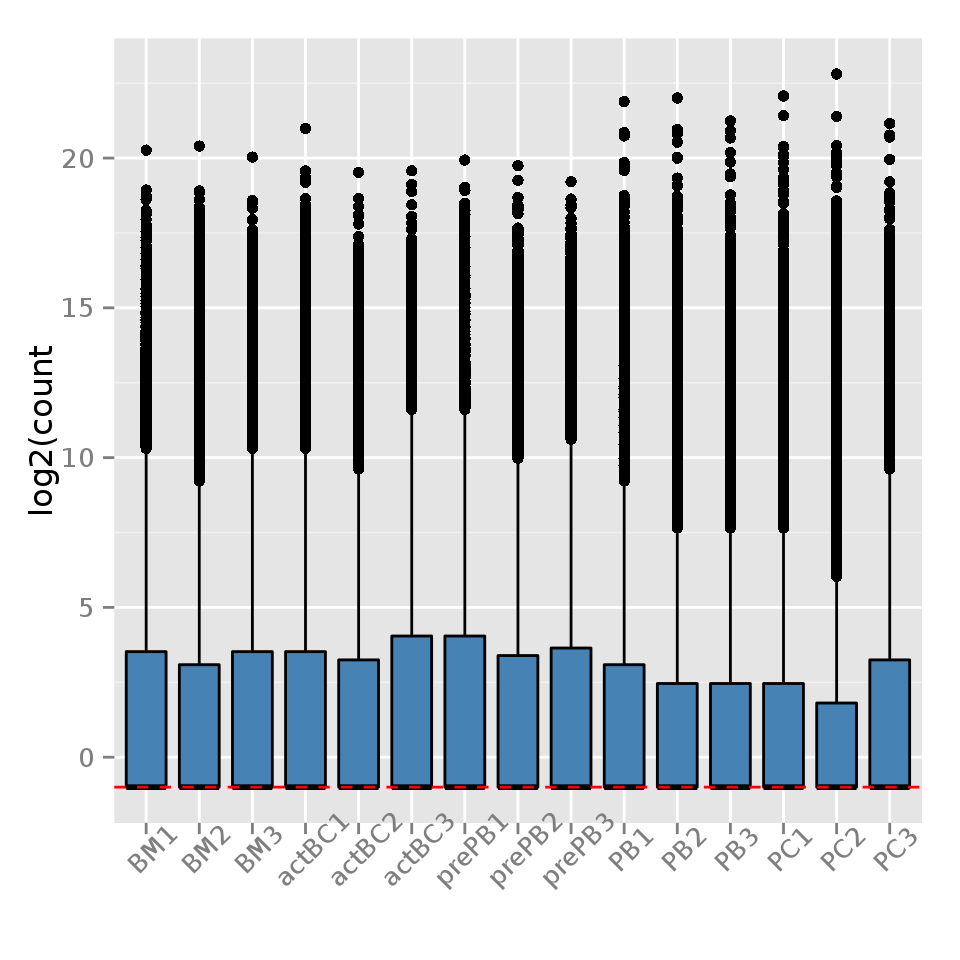

**Red line** is the global median accross all samples

## Frequency distribution of count

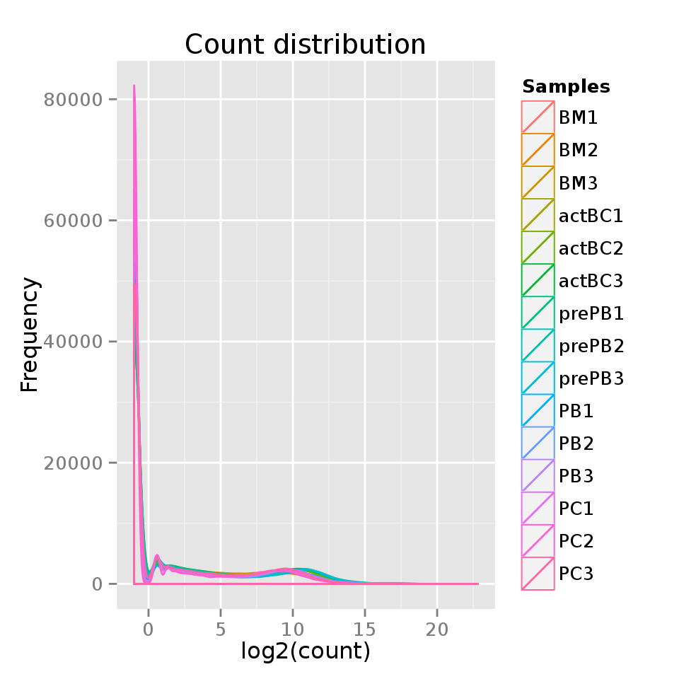

Remove genes with zero count:

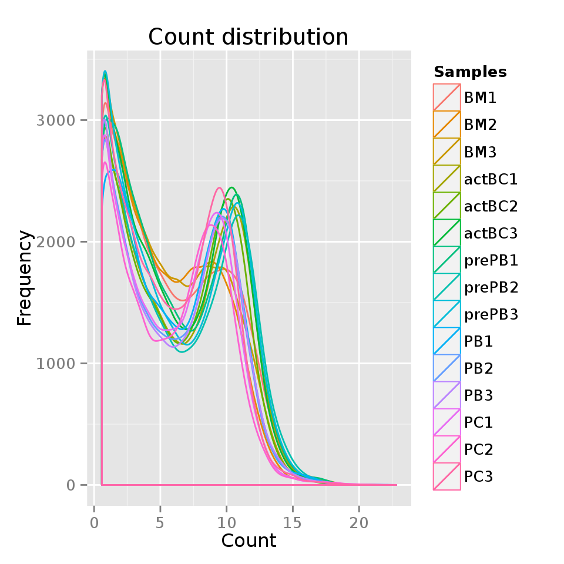

## Ensembl gene biotype enrichment

### Statistic for each sample

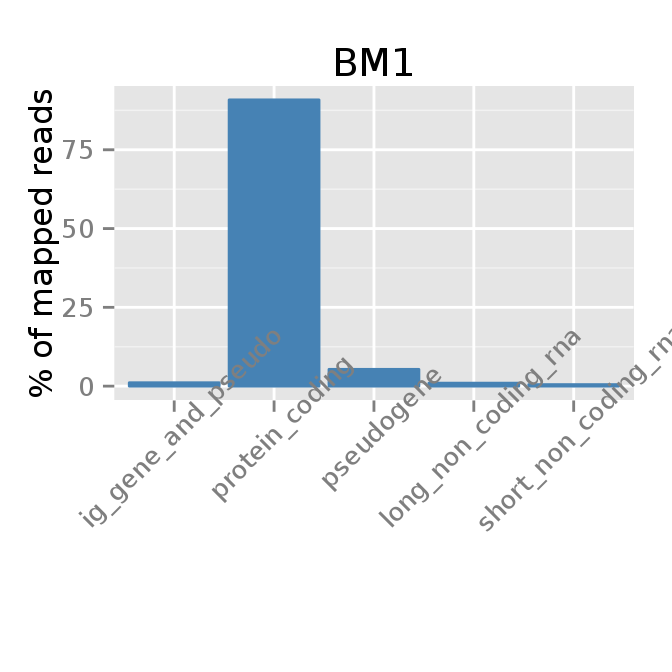

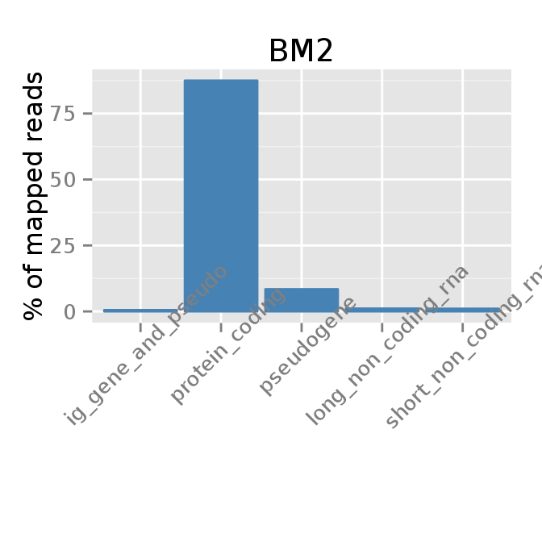

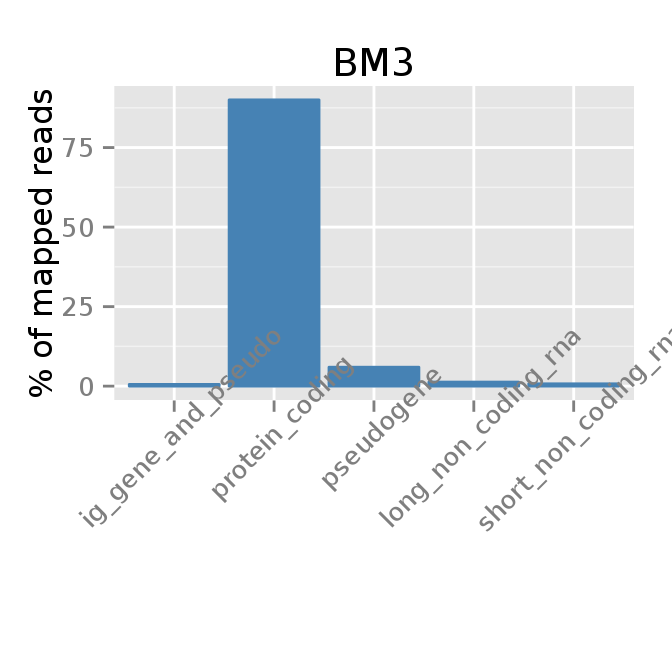

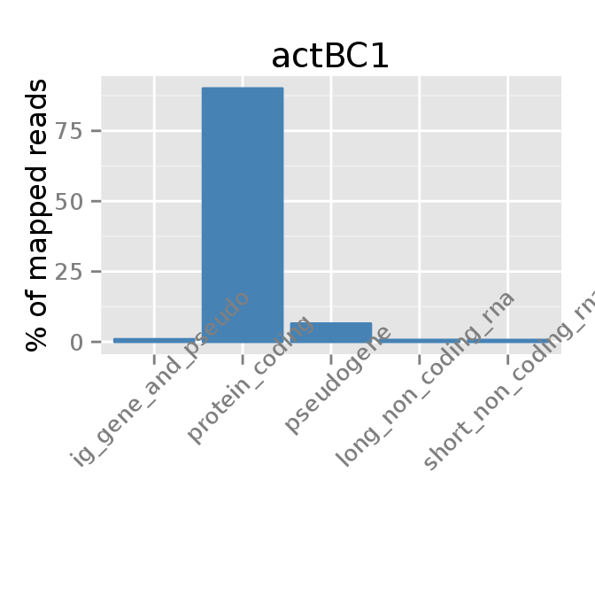

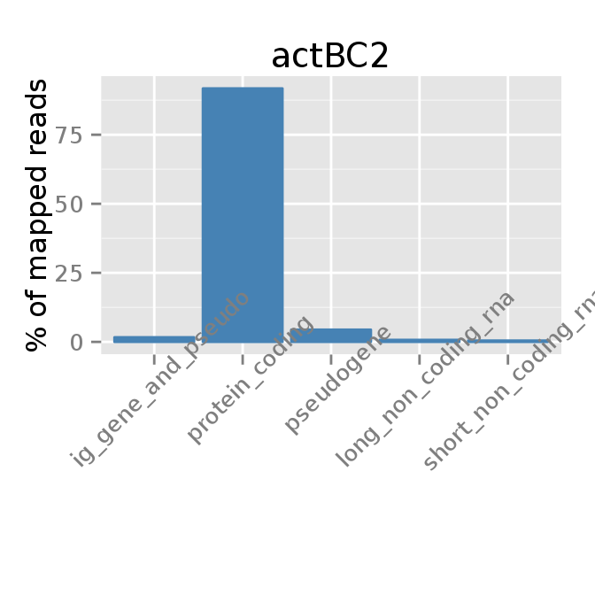

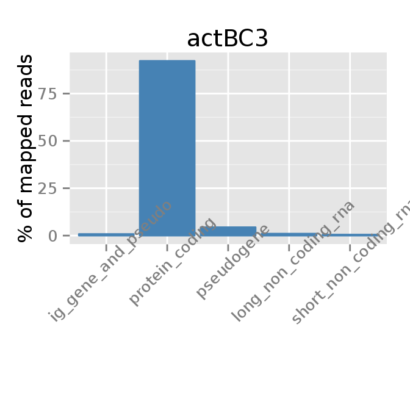

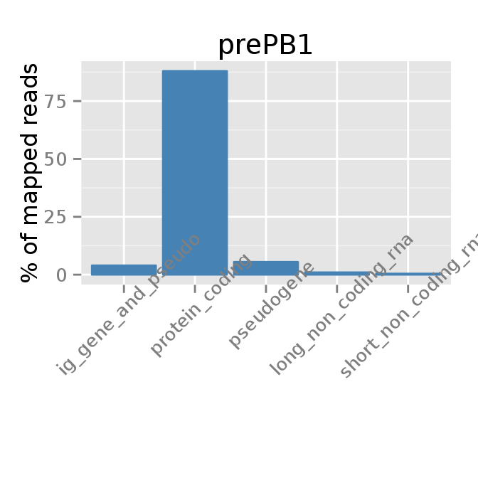

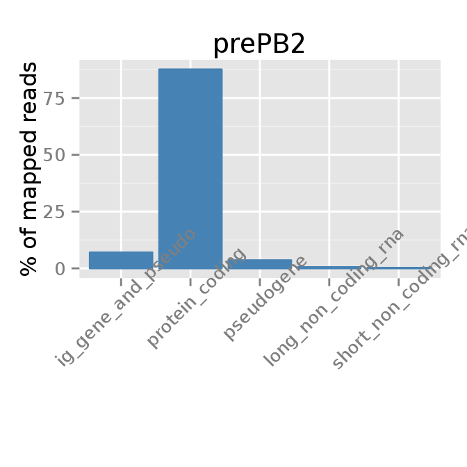

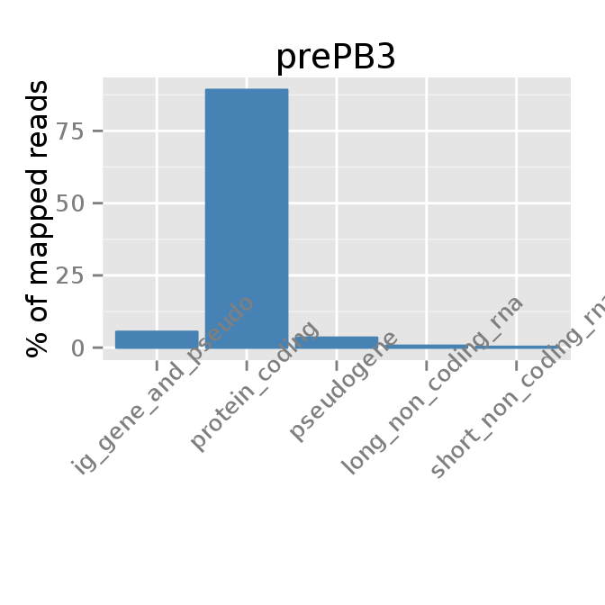

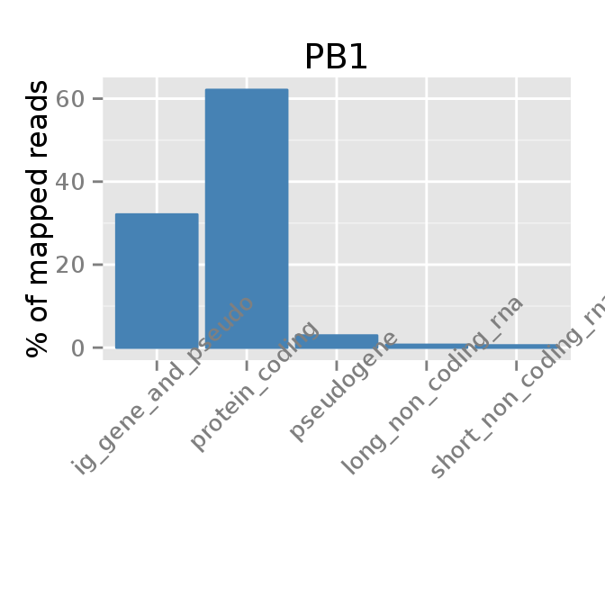

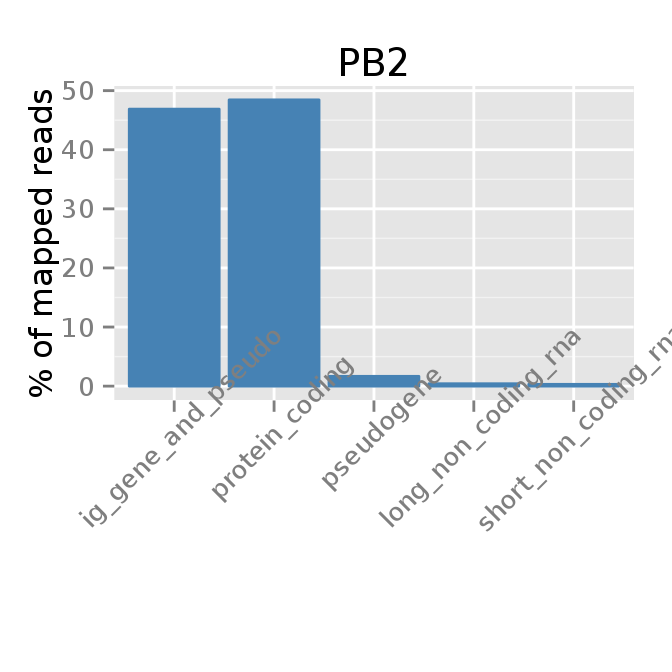

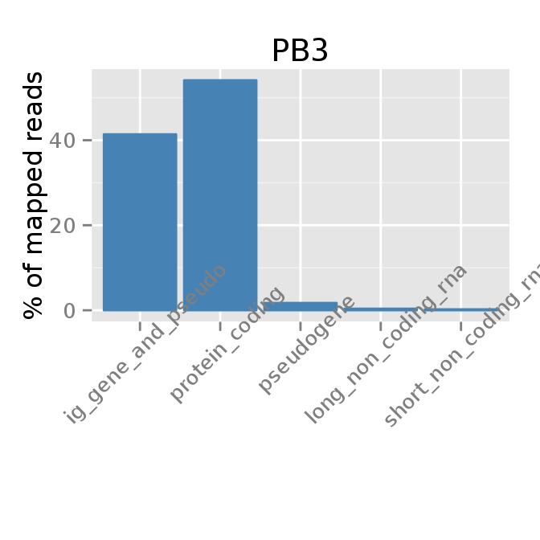

[3 more figures not shown]

### Global stat accross all samples:

```
##                                                               biotype read_count
## 3prime_overlapping_ncrna                     3prime_overlapping_ncrna      73358
## IG_C_gene                                                   IG_C_gene   68982749
## IG_C_pseudogene                                       IG_C_pseudogene    1353505
## IG_D_gene                                                   IG_D_gene      10002
## IG_J_gene                                                   IG_J_gene    2361672
## IG_J_pseudogene                                       IG_J_pseudogene      15327
## IG_V_gene                                                   IG_V_gene   58739214
## IG_V_pseudogene                                       IG_V_pseudogene    1221947
## Mt_rRNA                                                       Mt_rRNA    2356342
## Mt_tRNA                                                       Mt_tRNA     130022
## TEC                                                               TEC        375
## TR_C_gene                                                   TR_C_gene      23368
## TR_D_gene                                                   TR_D_gene          0
## TR_J_gene                                                   TR_J_gene       3925
## TR_J_pseudogene                                       TR_J_pseudogene         14
## TR_V_gene                                                   TR_V_gene       2501
## TR_V_pseudogene                                       TR_V_pseudogene        291
## antisense                                                   antisense    1230317
## lincRNA                                                       lincRNA    1864699
## miRNA                                                           miRNA      93069
## misc_RNA                                                     misc_RNA      43899
## polymorphic_pseudogene                         polymorphic_pseudogene      28136
## processed_pseudogene                             processed_pseudogene   18408746
## processed_transcript                             processed_transcript    1075397
## protein_coding                                         protein_coding  454514619
## pseudogene                                                 pseudogene          0
## rRNA                                                             rRNA       7658
## ribozyme                                                     ribozyme          0
## scaRNA                                                         scaRNA        581
## sense_intronic                                         sense_intronic     133972
## sense_overlapping                                   sense_overlapping     110638
## snRNA                                                           snRNA      32214
## snoRNA                                                         snoRNA      26599
## transcribed_processed_pseudogene     transcribed_processed_pseudogene    1086615
## transcribed_unitary_pseudogene         transcribed_unitary_pseudogene          4
## transcribed_unprocessed_pseudogene transcribed_unprocessed_pseudogene    1271061
## translated_unprocessed_pseudogene   translated_unprocessed_pseudogene          0
## unitary_pseudogene                                 unitary_pseudogene      67491
## unprocessed_pseudogene                         unprocessed_pseudogene    2790607
## vaultRNA                                                     vaultRNA         17
```

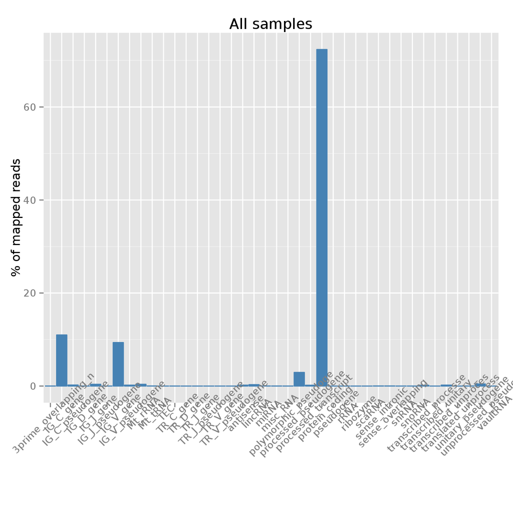

Source:

- http://www.ensembl.org/Help/Glossary
- http://www.ensembl.org/Help/Faq?id=468
- Read more [here](http://vega.sanger.ac.uk/info/about/gene_and_transcript_types.html)
- http://www.gencodegenes.org/gencode_biotypes.html

The biotypes can be grouped into protein coding, pseudogene, long noncoding and short noncoding. Examples of biotypes in each group are as follows:

A gene or transcript classification. Transcript types include protein coding, pseudogene, and long non-coding and short non-coding RNAs. For human, mouse and selected other species we incorporate manual annotation from Havana. Where a gene or transcript has been manually annotated, we use the manually assigned biotype. The full list of biotypes used by Havana are here.

The biotypes can be grouped into protein coding, pseudogene, long noncoding and short noncoding. Examples of biotypes in each group are as follows:

1. Protein coding:
- IG_C_gene, IG_D_gene, IG_J_gene, IG_LV_gene, IG_M_gene, IG_V_gene, IG_Z_gene, nonsense_mediated_decay, nontranslating_CDS, non_stop_decay, polymorphic_pseudogene, protein_coding, TR_C_gene, TR_D_gene, TR_gene, TR_J_gene, TR_V_gene.
2. Pseudogene:
- disrupted_domain, IG_C_pseudogene, IG_J_pseudogene, IG_pseudogene, IG_V_pseudogene, processed_pseudogene, pseudogene, transcribed_processed_pseudogene, transcribed_unprocessed_pseudogene, translated_processed_pseudogene, translated_unprocessed_pseudogene, TR_J_pseudogene, TR_V_pseudogene, unitary_pseudogene, unprocessed_pseudogene
3. Long noncoding:
- 3prime_overlapping_ncrna, ambiguous_orf, antisense, lincRNA, ncrna_host, non_coding, processed_transcript, retained_intron, sense_intronic, sense_overlapping
4. Short noncoding:
- miRNA, miRNA_pseudogene, misc_RNA, misc_RNA_pseudogene, Mt_rRNA, Mt_tRNA, Mt_tRNA_pseudogene, ncRNA, pre_miRNA, RNase_MRP_RNA, RNase_P_RNA, rRNA, rRNA_pseudogene, scRNA_pseudogene, snlRNA, snoRNA, snoRNA_pseudogene, snRNA, snRNA_pseudogene, SRP_RNA, tmRNA,, tRNA, tRNA_pseudogene